# CapstoneF3(1.1)_LALIT_SHARMA

```python
import numpy as np
import pandas as pd
import matplotlib.pyplot as plt
import seaborn as sns
from sklearn import linear_model
from sklearn.linear_model import LinearRegression
```

```python
df = pd.read_csv("C:/car_sales3.csv")
df.head()
```

|  | Sales_ID | name | year | selling_price | km_driven | State or Province | City | fuel | seller_type | transmission | owner | mileage | engine | max_power | seats |
| --- | --- | --- | --- | --- | --- | --- | --- | --- | --- | --- | --- | --- | --- | --- | --- |
| 0 | 1 | Maruti Swift Dzire VDI | 2014 | 450000 | 145500 | District of Columbia | Washington | Diesel | Individual | Manual | First Owner | 23.40 | 1248 | 74.00 | 5 |
| 1 | 2 | Skoda Rapid 1.5 TDI Ambition | 2014 | 370000 | 120000 | New York | New York City | Diesel | Individual | Manual | Second Owner | 21.14 | 1498 | 103.52 | 5 |
| 2 | 3 | Honda City 2017-2020 EXi | 2006 | 158000 | 140000 | Illinois | Chicago | Petrol | Individual | Manual | Third Owner | 17.70 | 1497 | 78.00 | 5 |
| 3 | 4 | Hyundai i20 Sportz Diesel | 2010 | 225000 | 127000 | Illinois | Chicago | Diesel | Individual | Manual | First Owner | 23.00 | 1396 | 90.00 | 5 |
| 4 | 5 | Maruti Swift VXI BSIII | 2007 | 130000 | 120000 | New York | New York City | Petrol | Individual | Manual | First Owner | 16.10 | 1298 | 88.20 | 5 |

```python
y = df["selling_price"]
y.head()
```

```
0    450000
1    370000
2    158000
3    225000
4    130000
Name: selling_price, dtype: int64
```

```python
X = df.drop(['Sales_ID'], axis=1)
X = df.drop(['selling_price'], axis=1)
X.head()
```

|  | Sales_ID | name | year | km_driven | State or Province | City | fuel | seller_type | transmission | owner | mileage | engine | max_power | seats |
| --- | --- | --- | --- | --- | --- | --- | --- | --- | --- | --- | --- | --- | --- | --- |
| 0 | 1 | Maruti Swift Dzire VDI | 2014 | 145500 | District of Columbia | Washington | Diesel | Individual | Manual | First Owner | 23.40 | 1248 | 74.00 | 5 |
| 1 | 2 | Skoda Rapid 1.5 TDI Ambition | 2014 | 120000 | New York | New York City | Diesel | Individual | Manual | Second Owner | 21.14 | 1498 | 103.52 | 5 |
| 2 | 3 | Honda City 2017-2020 EXi | 2006 | 140000 | Illinois | Chicago | Petrol | Individual | Manual | Third Owner | 17.70 | 1497 | 78.00 | 5 |
| 3 | 4 | Hyundai i20 Sportz Diesel | 2010 | 127000 | Illinois | Chicago | Diesel | Individual | Manual | First Owner | 23.00 | 1396 | 90.00 | 5 |
| 4 | 5 | Maruti Swift VXI BSIII | 2007 | 120000 | New York | New York City | Petrol | Individual | Manual | First Owner | 16.10 | 1298 | 88.20 | 5 |

1.1 a).Feature columns are significant in predicting the price of a used car as Y is target column remaining columns will be feature columns except sales_id column.

```python
cars_numeric = df.drop(['Sales_ID'], axis=1)
cars_numeric.head()
```

|  | name | year | selling_price | km_driven | State or Province | City | fuel | seller_type | transmission | owner | mileage | engine | max_power | seats |
| --- | --- | --- | --- | --- | --- | --- | --- | --- | --- | --- | --- | --- | --- | --- |
| 0 | Maruti Swift Dzire VDI | 2014 | 450000 | 145500 | District of Columbia | Washington | Diesel | Individual | Manual | First Owner | 23.40 | 1248 | 74.00 | 5 |
| 1 | Skoda Rapid 1.5 TDI Ambition | 2014 | 370000 | 120000 | New York | New York City | Diesel | Individual | Manual | Second Owner | 21.14 | 1498 | 103.52 | 5 |
| 2 | Honda City 2017-2020 EXi | 2006 | 158000 | 140000 | Illinois | Chicago | Petrol | Individual | Manual | Third Owner | 17.70 | 1497 | 78.00 | 5 |
| 3 | Hyundai i20 Sportz Diesel | 2010 | 225000 | 127000 | Illinois | Chicago | Diesel | Individual | Manual | First Owner | 23.00 | 1396 | 90.00 | 5 |
| 4 | Maruti Swift VXI BSIII | 2007 | 130000 | 120000 | New York | New York City | Petrol | Individual | Manual | First Owner | 16.10 | 1298 | 88.20 | 5 |

```python
print(cars_numeric.info())
```

```
<class 'pandas.core.frame.DataFrame'>
RangeIndex: 7906 entries, 0 to 7905
Data columns (total 14 columns):
 #   Column             Non-Null Count  Dtype
---  ------             --------------  -----
 0   name               7906 non-null   object
 1   year               7906 non-null   int64
 2   selling_price      7906 non-null   int64
 3   km_driven          7906 non-null   int64
 4   State or Province  7906 non-null   object
 5   City               7906 non-null   object
 6   fuel               7906 non-null   object
 7   seller_type        7906 non-null   object
 8   transmission       7906 non-null   object
 9   owner              7906 non-null   object
 10  mileage            7906 non-null   float64
 11  engine             7906 non-null   int64
 12  max_power          7906 non-null   float64
 13  seats              7906 non-null   int64
dtypes: float64(2), int64(5), object(7)
memory usage: 864.8+ KB
None
```

```python
cars_numeric = cars_numeric.select_dtypes(include=['float64', 'int64','object'])
cars_numeric.head()
cor = cars_numeric.corr()
cor
```

|  | year | selling_price | km_driven | mileage | engine | max_power | seats |
| --- | --- | --- | --- | --- | --- | --- | --- |
| year | 1.000000 | 0.412302 | -0.428548 | 0.328544 | 0.018263 | 0.226598 | -0.007923 |
| selling_price | 0.412302 | 1.000000 | -0.222158 | -0.126280 | 0.455682 | 0.749674 | 0.041617 |
| km_driven | -0.428548 | -0.222158 | 1.000000 | -0.172980 | 0.206031 | -0.038159 | 0.227259 |
| mileage | 0.328544 | -0.126280 | -0.172980 | 1.000000 | -0.576408 | -0.374621 | -0.451700 |
| engine | 0.018263 | 0.455682 | 0.206031 | -0.576408 | 1.000000 | 0.703975 | 0.611103 |
| max_power | 0.226598 | 0.749674 | -0.038159 | -0.374621 | 0.703975 | 1.000000 | 0.191999 |
| seats | -0.007923 | 0.041617 | 0.227259 | -0.451700 | 0.611103 | 0.191999 | 1.000000 |

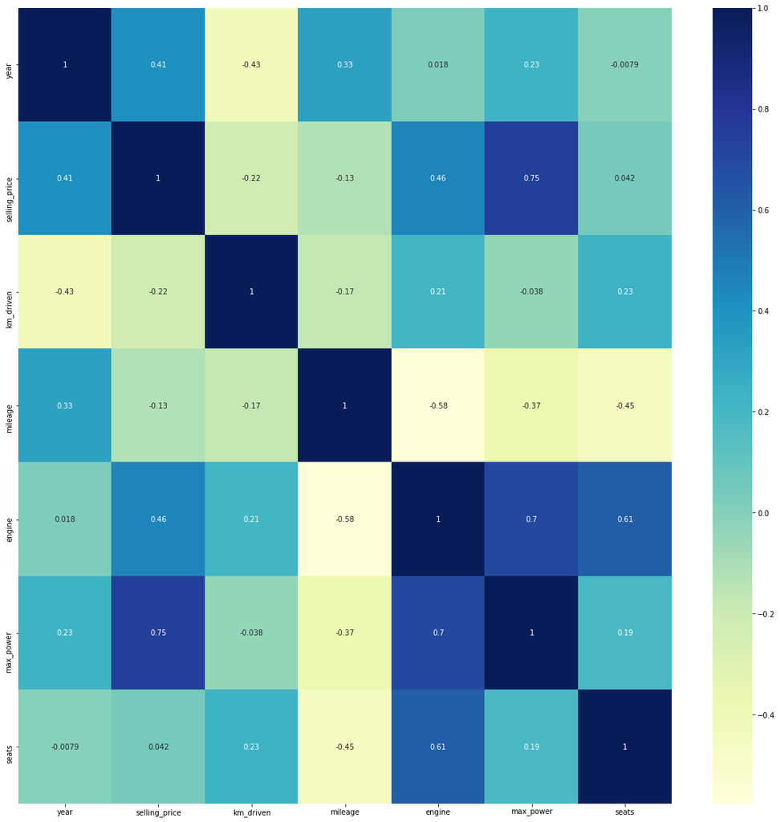

```python
plt.figure(figsize=(20,20))

# heatmap
sns.heatmap(cor, cmap="YlGnBu", annot=True)
plt.show()
```

1.1 b) For describing the price of a car we can use correlation function between target column and numerical feature coulmn here if value is>0.7. Generally, a value of r greater than 0.7 is considered a strong correlation. Anything between 0.5 and 0.7 is a moderate correlation, and anything less than 0.4 is considered a weak or no correlation. In our analysis max_power is highly correlated whereas Km_driven and mileage negatively correlated.

```python
data1 = pd.read_csv("C:/car_sales3.csv")
data2 = pd.read_csv("C:/sales_status.csv")
data3 = pd.merge(data1, data2,
                   on='Sales_ID',
                   how='outer')
data3.head()
```

|  | Sales_ID | name | year | selling_price | km_driven | State or Province | City | fuel | seller_type | transmission | owner | mileage | engine | max_power | seats | sold |
| --- | --- | --- | --- | --- | --- | --- | --- | --- | --- | --- | --- | --- | --- | --- | --- | --- |
| 0 | 1 | Maruti Swift Dzire VDI | 2014 | 450000 | 145500 | District of Columbia | Washington | Diesel | Individual | Manual | First Owner | 23.40 | 1248 | 74.00 | 5 | Y |
| 1 | 2 | Skoda Rapid 1.5 TDI Ambition | 2014 | 370000 | 120000 | New York | New York City | Diesel | Individual | Manual | Second Owner | 21.14 | 1498 | 103.52 | 5 | Y |
| 2 | 3 | Honda City 2017-2020 EXi | 2006 | 158000 | 140000 | Illinois | Chicago | Petrol | Individual | Manual | Third Owner | 17.70 | 1497 | 78.00 | 5 | Y |
| 3 | 4 | Hyundai i20 Sportz Diesel | 2010 | 225000 | 127000 | Illinois | Chicago | Diesel | Individual | Manual | First Owner | 23.00 | 1396 | 90.00 | 5 | Y |
| 4 | 5 | Maruti Swift VXI BSIII | 2007 | 130000 | 120000 | New York | New York City | Petrol | Individual | Manual | First Owner | 16.10 | 1298 | 88.20 | 5 | Y |

```python
result = data3.loc[data3['sold'] == 'Y']
result.head()
```

|  | Sales_ID | name | year | selling_price | km_driven | State or Province | City | fuel | seller_type | transmission | owner | mileage | engine | max_power | seats | sold |
| --- | --- | --- | --- | --- | --- | --- | --- | --- | --- | --- | --- | --- | --- | --- | --- | --- |
| 0 | 1 | Maruti Swift Dzire VDI | 2014 | 450000 | 145500 | District of Columbia | Washington | Diesel | Individual | Manual | First Owner | 23.40 | 1248 | 74.00 | 5 | Y |
| 1 | 2 | Skoda Rapid 1.5 TDI Ambition | 2014 | 370000 | 120000 | New York | New York City | Diesel | Individual | Manual | Second Owner | 21.14 | 1498 | 103.52 | 5 | Y |
| 2 | 3 | Honda City 2017-2020 EXi | 2006 | 158000 | 140000 | Illinois | Chicago | Petrol | Individual | Manual | Third Owner | 17.70 | 1497 | 78.00 | 5 | Y |
| 3 | 4 | Hyundai i20 Sportz Diesel | 2010 | 225000 | 127000 | Illinois | Chicago | Diesel | Individual | Manual | First Owner | 23.00 | 1396 | 90.00 | 5 | Y |
| 4 | 5 | Maruti Swift VXI BSIII | 2007 | 130000 | 120000 | New York | New York City | Petrol | Individual | Manual | First Owner | 16.10 | 1298 | 88.20 | 5 | Y |

```python
result['name'].value_counts()
```

```
Maruti Swift Dzire VDI               42
Maruti Alto 800 LXI                  21
BMW X4 M Sport X xDrive20d           19
Maruti Wagon R VXI BS IV             16
Maruti Wagon R LXI                   15
                                     ..
Volkswagen Vento Diesel Trendline     1
Maruti Ciaz AT ZXi                    1
Tata Indica Vista Quadrajet ZX        1
Toyota Innova 2.5 GX 7 STR            1
Maruti SX4 Vxi BSIII                  1
Name: name, Length: 968, dtype: int64
```

1.1 c) Maruti Swift Dzire VDI is selling more than any car after merging status csv file and main csv file

```python
result['City'].value_counts()
```

```
New York City    196
Los Angeles      191
Seattle           86
Chicago           83
Boston            69
                ...
Salem              1
Iowa City          1
Burlington         1
Colchester         1
Odessa             1
Name: City, Length: 275, dtype: int64
```

1.1 d) New york city is selling more than any other city

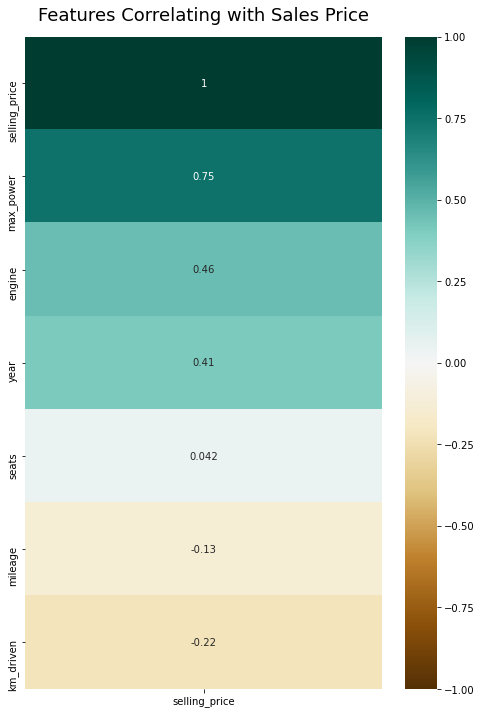

```python
plt.figure(figsize=(8, 12))
heatmap = sns.heatmap(cars_numeric.corr()[['selling_price']].sort_values(by='selling_price', ascending=False), vmin=-1, vmax=1, annot=True, cmap='BrBG')
heatmap.set_title('Features Correlating with Sales Price', fontdict={'fontsize':18}, pad=16);
```

1.1 e) This part is similar to part b we can see from the graph that max_power is more important in describing the selling price of car

```python
df.isnull().sum()
```

```
Sales_ID             0
name                 0
year                 0
selling_price        0
km_driven            0
State or Province    0
City                 0
fuel                 0
seller_type          0
transmission         0
owner                0
mileage              0
engine               0
max_power            0
seats                0
dtype: int64
```

1.2_stage2 8a) Here no value is empty so no need to handle missing value

```python
df.describe()
```

|  | Sales_ID | year | selling_price | km_driven | mileage | engine | max_power | seats |
| --- | --- | --- | --- | --- | --- | --- | --- | --- |
| count | 7906.000000 | 7906.000000 | 7.906000e+03 | 7.906000e+03 | 7906.000000 | 7906.000000 | 7906.000000 | 7906.000000 |
| mean | 4070.106248 | 2013.983936 | 6.498137e+05 | 6.918866e+04 | 19.419861 | 1458.708829 | 91.587374 | 5.416393 |
| std | 2345.770159 | 3.863695 | 8.135827e+05 | 5.679230e+04 | 4.036263 | 503.893057 | 35.747216 | 0.959208 |
| min | 1.000000 | 1994.000000 | 2.999900e+04 | 1.000000e+00 | 0.000000 | 624.000000 | 32.800000 | 2.000000 |
| 25% | 2037.250000 | 2012.000000 | 2.700000e+05 | 3.500000e+04 | 16.780000 | 1197.000000 | 68.050000 | 5.000000 |
| 50% | 4076.500000 | 2015.000000 | 4.500000e+05 | 6.000000e+04 | 19.300000 | 1248.000000 | 82.000000 | 5.000000 |
| 75% | 6102.000000 | 2017.000000 | 6.900000e+05 | 9.542500e+04 | 22.320000 | 1582.000000 | 102.000000 | 5.000000 |
| max | 8128.000000 | 2020.000000 | 1.000000e+07 | 2.360457e+06 | 42.000000 | 3604.000000 | 400.000000 | 14.000000 |

1.2_stage2 8c) Here for data transfromation and normalization we can use minmaxscaler. Transform features by scaling each feature to a given range. Normalization can be achieved using the scikit-learn library.

```python
Res= df[['Sales_ID','year','selling_price','km_driven','mileage','engine','max_power','seats']]
Res.head()
```

|  | Sales_ID | year | selling_price | km_driven | mileage | engine | max_power | seats |
| --- | --- | --- | --- | --- | --- | --- | --- | --- |
| 0 | 1 | 2014 | 450000 | 145500 | 23.40 | 1248 | 74.00 | 5 |
| 1 | 2 | 2014 | 370000 | 120000 | 21.14 | 1498 | 103.52 | 5 |
| 2 | 3 | 2006 | 158000 | 140000 | 17.70 | 1497 | 78.00 | 5 |
| 3 | 4 | 2010 | 225000 | 127000 | 23.00 | 1396 | 90.00 | 5 |
| 4 | 5 | 2007 | 130000 | 120000 | 16.10 | 1298 | 88.20 | 5 |

We can apply this methods on columns only so that they are of same type

```python
type(Res)
```

```
pandas.core.frame.DataFrame
```

```python
from sklearn.preprocessing import MinMaxScaler
```

```python
scaler=MinMaxScaler()
```

```python
Resu=scaler.fit_transform(Res)
```

```python
Resu
```

```
array([[0.00000000e+00, 7.69230769e-01, 4.21264752e-02, ...,
        2.09395973e-01, 1.12200436e-01, 2.50000000e-01],
       [1.23046635e-04, 7.69230769e-01, 3.41024038e-02, ...,
        2.93288591e-01, 1.92592593e-01, 2.50000000e-01],
       [2.46093269e-04, 4.61538462e-01, 1.28386146e-02, ...,
        2.92953020e-01, 1.23093682e-01, 2.50000000e-01],
       ...,
       [9.99753907e-01, 5.76923077e-01, 3.53060145e-02, ...,
        2.09395973e-01, 1.11928105e-01, 2.50000000e-01],
       [9.99876953e-01, 7.30769231e-01, 2.60783324e-02, ...,
        2.59060403e-01, 1.01307190e-01, 2.50000000e-01],
       [1.00000000e+00, 7.30769231e-01, 2.60783324e-02, ...,
        2.59060403e-01, 1.01307190e-01, 2.50000000e-01]])
```

1.2_stage2_b) Outlier analysis using boxplot (seaborn librar) on different numrical columns. They are calculated using IQR method and can be visualised using boxplots.

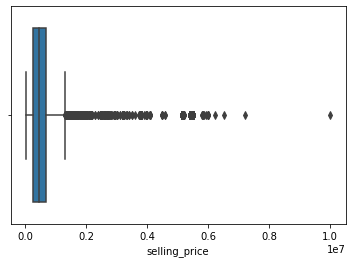

```python
sns.boxplot(x=Res["selling_price"])
```

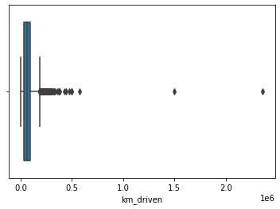

```python
sns.boxplot(x=Res["km_driven"])
```

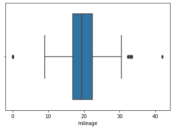

```python
sns.boxplot(x=Res["mileage"])
```

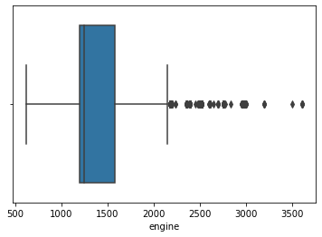

```python
sns.boxplot(x=Res["engine"])
```

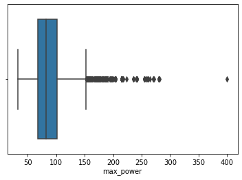

```python
sns.boxplot(x=Res["max_power"])
```

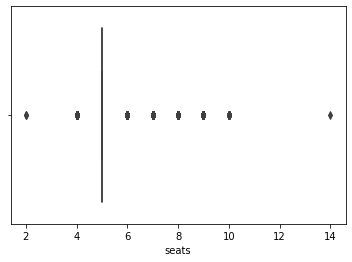

```python
sns.boxplot(x=Res["seats"])
```

A point beyond an inner fence on either side is considered a mild outlier. A point beyond an outer fence is considered an extreme outlier